# Manuscript Correction Summary

Project 1 - Spatial CRT

Author

Andrew Walther

Published

November 4, 2026

## Summary

While reviewing the paper and corresponding code for thesis integration, we found two coding errors that affect only the 3×3 and 3×4 grids. The summary script used the 2×4 BSS allocations for every grid, such that the BSS columns for 3×3 and 3×4 summarized two allocations that are not the block stratified design on those grids. The control-only spillover loop in the 3×3 and 3×4 simulation scripts also stopped at district 8 (for the 2x4 grid) instead of indexing to 9 and 12. Therefore, the higher-numbered (9-12) treated districts never passed spillover to their control neighbors. That second error changed the SRS control-only results only.

Fixing both issues changes two figures (Figures 6 and 7), two tables (Tables 2 and 3), the results paragraphs for the 3×3 and 3×4 grids, and one paragraph of the discussion section (the “checkerboard paradox”, which is removed). A handful of summary sentences elsewhere are altered to match the updated results. The methods, the 2×4 results (Table 1, Figure 5) and the North Carolina recommendation (Application) do not change.

## Findings and recommendation

Design with the lower mean MSE across the four ψ values in each setting. Bold marks a winner that differs from the 2×4 grid. The last column counts scenarios where the SD of MSE across allocations is smaller for BSS.

| Grid | Control Only ρ = 0.01 | Control Only ρ = 0 | Intervention & Control ρ = 0.01 | Intervention & Control ρ = 0 | BSS less variable |
| --- | --- | --- | --- | --- | --- |
| 2×4 (unchanged) | BSS 4/4 | SRS 4/4 | SRS 4/4 | SRS 4/4 | 16/16 |
| 3×3 before | BSS 4/4 | BSS 4/4 | BSS 4/4 | BSS 4/4 | 16/16 |
| 3×3 after | BSS 4/4 | BSS 4/4 | SRS 4/4 | SRS 4/4 | 8/16 |
| 3×4 before | BSS 4/4 | BSS 4/4 | SRS 4/4 | BSS 4/4 | 12/16 |
| 3×4 after | BSS 4/4 | SRS 4/4 | SRS 4/4 | SRS 4/4 | 14/16 |

Prior to the correction, the 3×3 grid showed BSS leading SRS everywhere, and the 3×4 grid showed BSS leading in every setting except intervention-and-control spillover with ρ = 0.01. Those results were derived from incorrect allocations. After the fix, the only disagreement between grids is control-only spillover with ρ = 0, where BSS still outperforms SRS on the 3×3 grid.

The paper's claims, checked against the corrected results.

| Claim in the accepted paper | After the correction |
| --- | --- |
| SRS vs. BSS is a risk-management trade-off (BSS stable, SRS better on average but variable) | Holds. Exception is 3×3 intervention-and-control spillover, where BSS is neither lower nor more stable |
| BSS preferred when spillover flows into controls, especially with spatial dependence | Holds, and now consistent across all three grids |
| SRS often has lower MSE when spillover reaches both arms | Holds, and stronger. SRS wins every such scenario on every grid (published 3×3 said the opposite) |
| MSE rises with ψ | Holds |
| Spatial dependence raises MSE for both designs | Holds for SRS on every grid. For BSS only on 3×3 (it was already false for 2×4 BSS as published) |
| SRS has lower bias, BSS lower variance | Holds for 2×4 and 3×4, not for 3×3 |
| BSS “consistently exhibits minimal MSE” | Dropped. Not true on any grid, including the unchanged 2×4 |
| 7 allocations are each optimal somewhere, BSS never the single best | BSS never best still holds. Counts are now 7, 4 and 6 (was 7, 7, 7) |
| “Checkerboard paradox” (BSS backfires under bidirectional spillover with ρ > 0) | Removed. The real mechanism is treatment-spillover collinearity in checkerboards (bias near −ψ) |
| NC probation recommendation (BSS when spillover flows mainly to controls) | Holds |

## Figures 6 and 7

In each pair the published figure is on the left and the corrected one on the right.

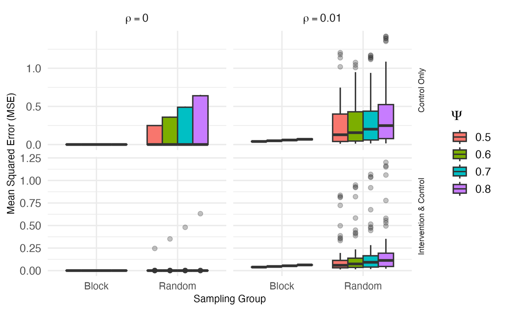

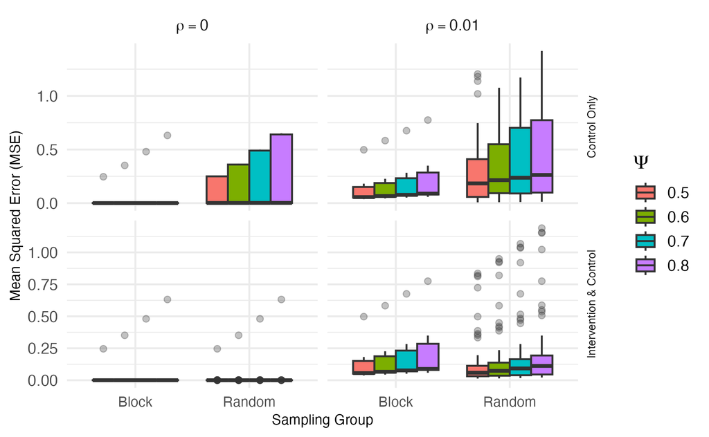

*Figure 6, 3×3 grid. The BSS boxes are now built from the six valid 3×3 allocations instead of the BSS allocations from the 2x4 grid. Under ρ = 0.01 they rise from near zero to a level below SRS for control-only spillover but above SRS for intervention-and-control spillover. Under ρ = 0 most BSS allocations still sit near zero, with one outlier (combo 77, a checkerboard-like allocation where $\hat{\beta}$ absorbs the spillover). The SRS control-only boxes rise slightly from the loop fix.*

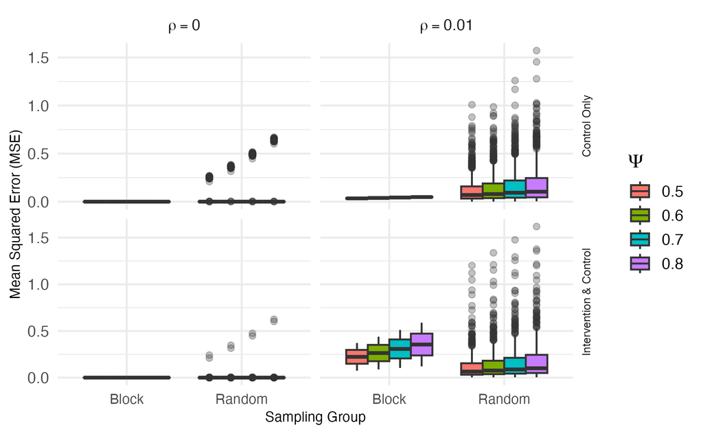

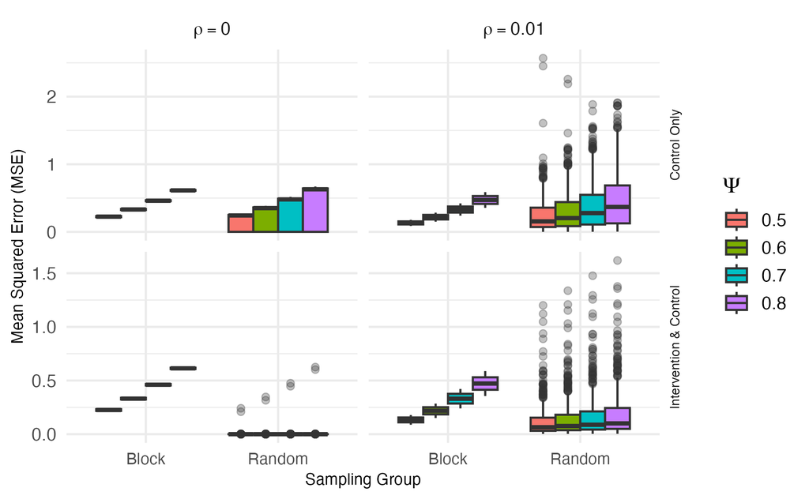

*Figure 7, 3×4 grid. Now BSS is the two 3×4 checkerboards (combos 313 and 612), which give identical results under both spillover types. Their MSE rises with ψ and sits well above zero in every panel. The SRS control-only boxes roughly double after the loop fix (y-axis now runs past MSE=2). The intervention-and-control SRS panels are unchanged.*

## Tables 2 and 3

Each cell shows the corrected value. When a value changed, the published value comes first and the cell is shaded. Units follow the mechanics of the original paper.

Manuscript Table 2 (3×3 grid), published → corrected. 75 of 96 cells changed.

| ψ | Simple Random Sampling MSE | Simple Random Sampling SD (×10) | Simple Random Sampling Bias | Block Stratified Sampling MSE | Block Stratified Sampling SD (×10) | Block Stratified Sampling Bias |
| --- | --- | --- | --- | --- | --- | --- |
| **Control Only, ρ = 0.01** |  |  |  |  |  |  |
| 0.5 | 0.234 → 0.274 | 2.593 → 2.631 | -0.054 → -0.089 | 0.041 → 0.147 | 0.044 → 1.799 | -0.012 → -0.054 |
| 0.6 | 0.276 → 0.330 | 2.860 → 2.964 | -0.092 → -0.135 | 0.050 → 0.174 | 0.080 → 2.115 | -0.018 → -0.064 |
| 0.7 | 0.322 → 0.390 | 3.284 → 3.472 | -0.131 → -0.181 | 0.059 → 0.205 | 0.114 → 2.460 | -0.022 → -0.073 |
| 0.8 | 0.372 → 0.455 | 3.857 → 4.140 | -0.170 → -0.227 | 0.069 → 0.240 | 0.145 → 2.839 | -0.025 → -0.083 |
| **Control Only, ρ = 0** |  |  |  |  |  |  |
| 0.5 | 0.092 → 0.114 | 1.207 → 1.247 | -0.182 → -0.226 | 0.001 → 0.042 | 0.002 → 1.002 | 0.003 → -0.078 |
| 0.6 | 0.132 → 0.164 | 1.740 → 1.798 | -0.219 → -0.271 | 0.001 → 0.059 | 0.002 → 1.434 | 0.003 → -0.096 |
| 0.7 | 0.180 → 0.223 | 2.370 → 2.449 | -0.255 → -0.316 | 0.001 → 0.081 | 0.002 → 1.959 | 0.003 → -0.113 |
| 0.8 | 0.235 → 0.291 | 3.099 → 3.203 | -0.292 → -0.362 | 0.001 → 0.106 | 0.002 → 2.577 | 0.003 → -0.130 |
| **Intervention & Control, ρ = 0.01** |  |  |  |  |  |  |
| 0.5 | 0.103 | 1.480 | 0.071 | 0.039 → 0.147 | 0.022 → 1.799 | -0.019 → -0.054 |
| 0.6 | 0.122 | 1.688 | 0.082 | 0.046 → 0.174 | 0.027 → 2.115 | -0.020 → -0.064 |
| 0.7 | 0.143 | 1.905 | 0.092 | 0.053 → 0.205 | 0.032 → 2.460 | -0.021 → -0.073 |
| 0.8 | 0.168 → 0.167 | 2.149 → 2.133 | 0.101 → 0.102 | 0.063 → 0.240 | 0.010 → 2.839 | -0.019 → -0.083 |
| **Intervention & Control, ρ = 0** |  |  |  |  |  |  |
| 0.5 | 0.002 | 0.219 | -0.004 | 0.001 → 0.042 | 0.004 → 1.002 | 0.004 → -0.078 |
| 0.6 | 0.003 | 0.313 | -0.004 | 0.001 → 0.059 | 0.004 → 1.434 | 0.004 → -0.096 |
| 0.7 | 0.004 | 0.428 | -0.005 | 0.001 → 0.081 | 0.004 → 1.959 | 0.004 → -0.113 |
| 0.8 | 0.005 | 0.562 | -0.006 | 0.001 → 0.106 | 0.004 → 2.577 | 0.004 → -0.130 |

In Table 2, the published BSS values of about 0.001 under ρ = 0 come from two allocations that are not block stratified on 3×3. For the six valid allocations, BSS MSE is 0.042 to 0.106 and still well below SRS for control-only spillover, but above SRS for intervention-and-control spillover. The one SRS change under intervention-and-control spillover (ψ = 0.8, ρ = 0.01) comes from regenerating a stored result file and only the third decimal place is altered.

Manuscript Table 3 (3×4 grid), published → corrected. 72 of 96 cells changed.

| ψ | Simple Random Sampling MSE | Simple Random Sampling SD (×100) | Simple Random Sampling Bias | Block Stratified Sampling MSE (×10) | Block Stratified Sampling SD (×100) | Block Stratified Sampling Bias |
| --- | --- | --- | --- | --- | --- | --- |
| **Control Only, ρ = 0.01** |  |  |  |  |  |  |
| 0.5 | 0.120 → 0.244 | 13.244 → 24.422 | 0.033 → -0.190 | 0.346 → 1.332 | 0.963 → 6.416 | -0.152 → -0.273 |
| 0.6 | 0.138 → 0.311 | 14.807 → 28.926 | 0.021 → -0.242 | 0.388 → 2.180 | 0.505 → 9.471 | -0.167 → -0.391 |
| 0.7 | 0.159 → 0.390 | 17.166 → 34.937 | 0.009 → -0.292 | 0.434 → 3.309 | 0.011 → 12.806 | -0.180 → -0.509 |
| 0.8 | 0.183 → 0.480 | 20.387 → 42.507 | -0.001 → -0.341 | 0.484 → 4.721 | 0.561 → 16.429 | -0.193 → -0.627 |
| **Control Only, ρ = 0** |  |  |  |  |  |  |
| 0.5 | 0.034 → 0.133 | 8.554 → 12.497 | -0.068 → -0.264 | 0.004 → 2.255 | 0.022 → 2.274 | -0.006 → -0.463 |
| 0.6 | 0.049 → 0.191 | 12.318 → 18.005 | -0.081 → -0.317 | 0.004 → 3.315 | 0.022 → 2.196 | -0.006 → -0.570 |
| 0.7 | 0.067 → 0.260 | 16.769 → 24.518 | -0.094 → -0.370 | 0.004 → 4.609 | 0.020 → 1.991 | -0.006 → -0.676 |
| 0.8 | 0.087 → 0.339 | 21.912 → 32.042 | -0.108 → -0.423 | 0.003 → 6.137 | 0.016 → 1.659 | -0.006 → -0.782 |
| **Intervention & Control, ρ = 0.01** |  |  |  |  |  |  |
| 0.5 | 0.112 | 12.873 | 0.022 | 2.229 → 1.332 | 20.995 → 6.416 | -0.415 → -0.273 |
| 0.6 | 0.131 | 14.762 | 0.021 | 2.634 → 2.180 | 24.750 → 9.471 | -0.452 → -0.391 |
| 0.7 | 0.151 | 16.817 | 0.020 | 3.074 → 3.309 | 28.774 → 12.806 | -0.488 → -0.509 |
| 0.8 | 0.173 | 19.046 | 0.018 | 3.548 → 4.721 | 33.060 → 16.429 | -0.525 → -0.627 |
| **Intervention & Control, ρ = 0** |  |  |  |  |  |  |
| 0.5 | 0.001 | 1.051 | -0.001 | 0.003 → 2.255 | 0.004 → 2.274 | -0.003 → -0.463 |
| 0.6 | 0.001 | 1.542 | -0.001 | 0.003 → 3.315 | 0.004 → 2.196 | -0.002 → -0.570 |
| 0.7 | 0.001 | 2.143 | -0.002 | 0.003 → 4.609 | 0.005 → 1.991 | -0.002 → -0.676 |
| 0.8 | 0.002 | 2.853 | -0.002 | 0.003 → 6.137 | 0.005 → 1.659 | -0.002 → -0.782 |

In Table 3, the BSS MSE (×10 in the table) increases from near zero to 0.226 to 0.614 on the original scale under ρ = 0. This is due to the fact that in a BSS allocation the spillover indicator equals 1 − x and $\hat{\beta}$ absorbs the spillover. The BSS bias is close to −ψ there (-0.463 at ψ = 0.5). The SRS control-only MSE approximately doubles, and its mean bias goes from slightly positive to clearly negative (0.033 to -0.190 at ψ = 0.5, ρ = 0.01). SRS under intervention-and-control spillover is unchanged.

## Text changes

The text edits are limited to statements that depended on the 3×3 and 3×4 numbers. Section names follow the manuscript.

Text changes, by manuscript section. CO = control-only spillover, IC = intervention-and-control spillover.

[output not shown]